Анализ распространения COVID-19

# Описание данных

## Контекст

- Всемирная организация здравоохранения - 31 декабря 2019 года ВОЗ была предупреждена о нескольких случаях пневмонии в городе Ухань, провинция Хубэй, Китай. Вирус не соответствует ни одному другому известному вирусу. Это вызвало обеспокоенность, потому что когда вирус новый, мы не знаем, как он влияет на людей.
- Таким образом, информация на ежедневном уровне о затронутых людях может дать некоторую интересную информацию, когда она станет доступной для более широкого сообщества специалистов в области данных.
- Данные принадлежат Университету Джона Хопкинса и получены на [Kaggle](https://www.kaggle.com/sudalairajkumar/novel-corona-virus-2019-dataset#time_series_covid_19_confirmed.csv).

## Содержание

- Новый коронавирус 2019 года (2019-COVID) - это вирус (точнее, коронавирус), идентифицированный как причина вспышки респираторного заболевания, впервые обнаруженной в Ухани, Китай. По сообщениям, на ранних стадиях многие из пациентов, участвовавших в вспышке заболевания в Ухане, Китай, имели какую-то связь с крупным рынком морепродуктов и животных, что предполагает распространение от человека к человеку. Однако растущее число пациентов, по сообщениям, не имело контакта с рынками животных, что указывает на то, что происходит распространение от человека к человеку. В настоящее время неясно, насколько легко или устойчиво этот вирус распространяется между людьми - CDC
- Данные содержат ежедневную информацию о количестве пораженных случаев, смертности и восстановлении после нового коронавируса 2019 года. Это данные временного ряда, и поэтому число дел в любой день является накопительным числом.
- Данные доступны с 22 января 2020 года.

## Описание столбцов

- 1) Sno - Серийный номер
- 2) ObservationDate - Дата наблюдения в ММ / ДД / ГГГГ
- 3) Провинция / Штат - Провинция или штат наблюдения (может отсутствовать при отсутствии)
- 4) Страна / Регион - Страна наблюдения
- 5) Последнее обновление - время в UTC, в которое строка обновляется для данной провинции или страны. (Не стандартизирован и поэтому, пожалуйста, очистите его перед использованием)
- 6) Подтверждено - Совокупное количество подтвержденных случаев до этой даты
- 7) Смертей - Общее число смертей на эту дату
- 8) Восстановлено - Совокупное количество восстановленных случаев до этой даты

# 1 Загрузим библиотеки

```python
import warnings
warnings.filterwarnings('ignore')

import numpy as np
import pandas as pd

from matplotlib import pyplot as plt

import plotly as py
import plotly.express as px
import plotly.graph_objs as go

from plotly.subplots import make_subplots
from plotly.offline import download_plotlyjs, init_notebook_mode, plot, iplot

init_notebook_mode(connected=True)
```

## 1.1 Объявим класс для исследования и наполним его методами

```python
class DataExplorer:

    def histogram(self, data, n_bins, range_start, range_end, grid, cumulative=False, x_label = '', y_label = '', title = ''):

        """
        Простая гистограмма

        Пример:
        histogram(df, 100, 0, 150, True, 'Количество иксов', 'Количество игриков', 'Заголовок')

        data - датасет
        n_bins - количество корзин
        range_start - минимальный икс для корзины
        range_end - максимальный икс для корзины
        grid - рисовать сетку или нет (False / True)


        histogram(data, n_bins, range_start, range_end, grid, x_label = "", y_label = "", title = "")
        """

        # Создаем объект - график
        _, ax = plt.subplots()

        # Задаем параметры
        ax.hist(data, bins = n_bins, range = (range_start, range_end), cumulative = cumulative, color = '#4169E1')

        # Добавляем сетку
        if grid == True:
            ax.grid(color='grey', linestyle='-', linewidth=0.5)
        else:
            pass

        # Добавляем медиану, среднее и квартили
        ax.axvline(data.median(),linestyle = '--', color = '#FF1493', label = 'median')
        ax.axvline(data.mean(),linestyle = '--', color = 'orange', label = 'mean')
        ax.axvline(data.quantile(0.1),linestyle = '--', color = 'yellow', label = '1%')
        ax.axvline(data.quantile(0.99),linestyle = '--', color = 'yellow', label = '99%')
        ax.legend()
        ax.set_ylabel(y_label)
        ax.set_xlabel(x_label)
        ax.set_title(title)


    def plotly_bar(self, data, x, y, color, x_axis_title, y_axis_title, title):
        """
        Рисует интерактивный столбчатый график

        Пример:
        explorer.plotly_bar(top_ten, 'city', 'average_flights', 'average_flights', '', 'Количество рейсов', 'Топ-10 городов по количеству рейсов')
        """

        fig = px.bar(data, x=data[x], y=data[y], color=color, color_continuous_scale='portland')

        fig.update_layout(title=title,
        xaxis_title=x_axis_title,
        yaxis_title=y_axis_title,
        font=dict(
        family="Garamond', monospace",
        size=13,
        color='#7f7f7f'),
        template='plotly_white',
        showlegend=False)

        fig.show()


    def plotly_choropleth(self, data, z='confirmed', title=''):
        """
        Рисует интерактивную карту

        Пример:
        explorer.plotly_choropleth(z='recovered', title='Число вылечившхся на 07.04.2020 года')
        """

        fig = go.Figure(data=go.Choropleth(
            locations = data['country'],
            locationmode = 'country names',
            z = data[z],
            colorscale = 'Redor',
            marker_line_color = 'black',
            marker_line_width = 0.5,
        ))

        fig.update_layout(title_text = title,
                          title_x = 0.5,
                          geo=dict(showframe = False, showcoastlines = False, projection_type = 'equirectangular'))

        fig.show()


    def plotly_animated_choropleth(self, data, color='confirmed', title=''):
        fig = px.choropleth(data,
                    locations='country',
                    locationmode = 'country names',
                    color=color,
                    hover_name='country',
                    animation_frame='date'
                   )
        fig.update_layout(
            title_text = title,
            title_x = 0.5,
            geo=dict(
                showframe = False,
                showcoastlines = False,
            ))

        fig.show()

    def plotly_sided_bar(self, data):
        fig = go.Figure()
        fig.add_trace(go.Bar(
            x=data['country'],
            y=data['confirmed'],
            name='confirmed',
            marker_color='blue'
        ))
        fig.add_trace(go.Bar(
            x=data['country'],
            y=data['recovered'],
            name='recovered',
            marker_color='red'))
        fig.add_trace(go.Bar(
            x=data['country'],
            y=data['deaths'],
            name='deaths',
            marker_color='green'
        ))
        fig.update_layout(font=dict(family="Garamond', monospace",
                                    size=13,
                                    color='#7f7f7f'),
                          template='plotly_white',
                          xaxis_tickangle=-45,
                          showlegend=True)
        fig.show()

    def plotly_stack(self, data):
        fig = go.Figure(data=[
            go.Bar(name='confirmed', x=data['country'], y=data['confirmed']),
            go.Bar(name='recovered', x=data['country'], y=data['recovered']),
            go.Bar(name='deaths', x=data['country'], y=data['deaths'])
        ])

        fig.update_layout(barmode='stack',
                          font=dict(family="Garamond', monospace",
                                    size=13,
                                    color='#7f7f7f'),
                          template='plotly_white',
                          xaxis_tickangle=-45,
                          showlegend=True)
        fig.show()


    def firstsight(self, data):

        """
        Возврашает пять первых, последних и случайных элементов датасета для дальнейшего вывода с помощью Display

        Пример:
        head, tail, sample = explorer.firstsight(df)
        """

        head = data.head(5)
        tail = data.tail(5)
        sample = data.sample(5)

        return head, tail, sample

    def reporter(self, confirmed, deaths, recovered):
        cfr = (deaths / (deaths + recovered)) * 100

        print('1. По состоянию на 07.04.2020 года:' + '\n' +
              ' - заболело {} '.format(confirmed)  + 'человек' + '\n' +
              ' - умерло {} '.format(deaths)  + 'человек' + '\n' +
              ' - выздоровело {} '.format(recovered)  + 'человек' + '\n' +
              '2. На сегодняшний день, исходя из представленных данных ,' +
              'принимая во внимание короткий период наблюдений летальность COVID-19 ' +
              'составляет {:.2f} %'.format(cfr))

    class Display(object):
        """
        Выводит HTML представление нескольких объектов

        Пример:
        Display(head, tail, sample)

        """
        template = """<div style="float: left; padding: 10px;">
        <p style='font-family:"Courier New", Courier, monospace'>{0}</p>{1}
        </div>"""
        def __init__(self, *args):
            self.args = args

        def _repr_html_(self):
            return '\n'.join(self.template.format(a, eval(a)._repr_html_())
                             for a in self.args)

        def __repr__(self):
            return '\n\n'.join(a + '\n' + repr(eval(a))
                               for a in self.args)
```

```python
explorer = DataExplorer()
```

# 2 Ознакомимся с данными

## 2.1 Прочитаем данные в переменную

```python
df = pd.read_csv('covid_19_data.csv')
```

## 2.2 Выведем первые, последние и случайные пять строк

```python
head, tail, sample = explorer.firstsight(df)
explorer.Display('head', 'tail', 'sample')
```

head

|  | SNo | ObservationDate | Province/State | Country/Region | Last Update | Confirmed | Deaths | Recovered |
| --- | --- | --- | --- | --- | --- | --- | --- | --- |
| 0 | 1 | 01/22/2020 | Anhui | Mainland China | 1/22/2020 17:00 | 1.0 | 0.0 | 0.0 |
| 1 | 2 | 01/22/2020 | Beijing | Mainland China | 1/22/2020 17:00 | 14.0 | 0.0 | 0.0 |
| 2 | 3 | 01/22/2020 | Chongqing | Mainland China | 1/22/2020 17:00 | 6.0 | 0.0 | 0.0 |
| 3 | 4 | 01/22/2020 | Fujian | Mainland China | 1/22/2020 17:00 | 1.0 | 0.0 | 0.0 |
| 4 | 5 | 01/22/2020 | Gansu | Mainland China | 1/22/2020 17:00 | 0.0 | 0.0 | 0.0 |

tail

|  | SNo | ObservationDate | Province/State | Country/Region | Last Update | Confirmed | Deaths | Recovered |
| --- | --- | --- | --- | --- | --- | --- | --- | --- |
| 12884 | 12885 | 04/07/2020 | Wyoming | US | 2020-04-07 23:11:31 | 216.0 | 0.0 | 0.0 |
| 12885 | 12886 | 04/07/2020 | Xinjiang | Mainland China | 2020-04-07 23:11:31 | 76.0 | 3.0 | 73.0 |
| 12886 | 12887 | 04/07/2020 | Yukon | Canada | 2020-04-07 23:11:31 | 7.0 | 0.0 | 0.0 |
| 12887 | 12888 | 04/07/2020 | Yunnan | Mainland China | 2020-04-07 23:11:31 | 184.0 | 2.0 | 173.0 |
| 12888 | 12889 | 04/07/2020 | Zhejiang | Mainland China | 2020-04-07 23:11:31 | 1265.0 | 1.0 | 1230.0 |

sample

|  | SNo | ObservationDate | Province/State | Country/Region | Last Update | Confirmed | Deaths | Recovered |
| --- | --- | --- | --- | --- | --- | --- | --- | --- |
| 4618 | 4619 | 03/10/2020 | NaN | Peru | 2020-03-10T16:33:13 | 11.0 | 0.0 | 0.0 |
| 3049 | 3050 | 03/02/2020 | NaN | Dominican Republic | 2020-03-02T16:33:02 | 1.0 | 0.0 | 0.0 |
| 6175 | 6176 | 03/17/2020 | NaN | Austria | 2020-03-17T15:33:06 | 1332.0 | 3.0 | 1.0 |
| 4334 | 4335 | 03/09/2020 | NaN | Slovenia | 2020-03-08T17:03:16 | 16.0 | 0.0 | 0.0 |
| 1081 | 1082 | 02/09/2020 | NaN | Singapore | 2020-02-09T02:43:02 | 40.0 | 0.0 | 2.0 |

⚡ **Вывод:**

1. В датасете есть пропуски в столбце 'Province/State' - данные отсутствуют в отношении стран с унитарным устройством,
2. Столбцы с серийным номером (SNo), точная дата и время обновления (Last Update), наименование региона (LastProvince/State) - кандидаты на удаление в силу неинформативности.
3. Число зараженных, смертей и вылечевшихся потребует приведению к целочисленному типу данных.
4. Визуальное ознакомление не выявило существенных проблем с данными.
5. Данные представлены за период от 22.01.2020 года до 07.04.2020 года.

## 2.3 Выведем общую информацию о датасете, общую статистику, проверим дубликаты, уникальные значения

#### - общая информация и статистика о датасете

```python
df.info()
```

```
<class 'pandas.core.frame.DataFrame'>
RangeIndex: 12889 entries, 0 to 12888
Data columns (total 8 columns):
SNo                12889 non-null int64
ObservationDate    12889 non-null object
Province/State     6687 non-null object
Country/Region     12889 non-null object
Last Update        12889 non-null object
Confirmed          12889 non-null float64
Deaths             12889 non-null float64
Recovered          12889 non-null float64
dtypes: float64(3), int64(1), object(4)
memory usage: 805.7+ KB
```

```python
df.describe().T
```

|  | count | mean | std | min | 25% | 50% | 75% | max |
| --- | --- | --- | --- | --- | --- | --- | --- | --- |
| SNo | 12889.0 | 6445.000000 | 3720.878145 | 1.0 | 3223.0 | 6445.0 | 9667.0 | 12889.0 |
| Confirmed | 12889.0 | 1465.407945 | 8477.771878 | 0.0 | 5.0 | 49.0 | 331.0 | 141942.0 |
| Deaths | 12889.0 | 68.504073 | 632.034355 | 0.0 | 0.0 | 0.0 | 3.0 | 17127.0 |
| Recovered | 12889.0 | 372.512530 | 3385.954419 | 0.0 | 0.0 | 1.0 | 22.0 | 64073.0 |

```python
df.describe(include=['object']).T
```

|  | count | unique | top | freq |
| --- | --- | --- | --- | --- |
| ObservationDate | 12889 | 77 | 04/07/2020 | 320 |
| Province/State | 6687 | 297 | Diamond Princess cruise ship | 102 |
| Country/Region | 12889 | 219 | US | 2556 |
| Last Update | 12889 | 1819 | 3/8/20 5:31 | 921 |

#### - проверим наличие полных дубликатов

```python
df.duplicated().sum()
```

```
0
```

# 3 Изменим регистр в наименовании столбцов, перименуем столбцы, приведенм данные к целочисленному типу

#### - приведем к строчному написанию заголовки столбцов

```python
df.columns = map(str.lower, df.columns)
```

#### - переименуем столбцы с датой, регионом и страной, отбросим столбец 'last update' и 'sno' как неинформативные

```python
df.drop(['sno','last update'], axis=1, inplace=True)
```

```python
df.rename(columns={'observationdate': 'date',
                   'province/state': 'state',
                   'country/region':'country'}, inplace=True)
```

#### - приведем столбы с наблюдениями о числе зараженных, умерших и выздоровевших в целочисленный тип, поскольку это дискретные величины

```python
df['confirmed'] = df.confirmed.astype('int')
df['deaths'] = df.deaths.astype('int')
df['recovered'] = df.recovered.astype('int')
```

# 4 Ознакомимся с данными в столбцах

#### - confirmed (число подтвержденных случаев)

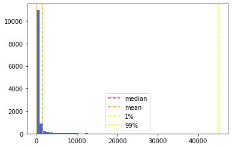

```python
explorer.histogram(df.confirmed, 50, 0, 40000, grid=False)
```

Распредление скошено вправо, есть длинный хвост, пик у нуля. Построим ящик с усами с уменьшенным масштабом:

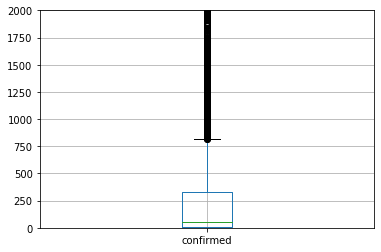

```python
plt.ylim(0, 2000)
df.boxplot('confirmed')
```

Множественные выбросы, которые существенно влияют на среднее и медиану: ряд стран значительно опережают другие по числу зараженных.

#### - deaths (число смертей)

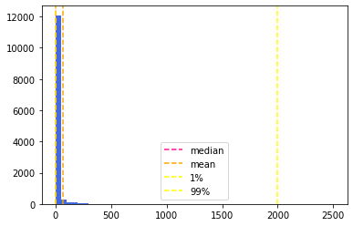

```python
explorer.histogram(df.deaths, 50, 0, 2500, grid=False)
```

Распредление также скошено вправо и есть длинный хвост, хотя пик у нуля. Построим для числа смертей ящик с усами с уменьшенным масштабом:

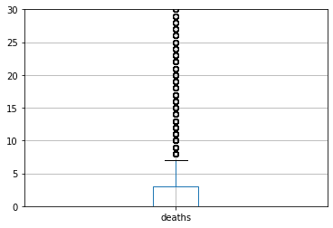

```python
plt.ylim(0, 30)
df.boxplot('deaths')
```

Также множественные выбросы: то же наблюдение - ряд стран значительно опережают другие по числу смертей от COVID-19.

#### - recovered (число вылечившихся)

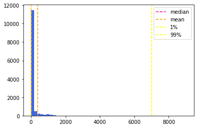

```python
explorer.histogram(df.recovered, 50, 0, 9000, grid=False)
```

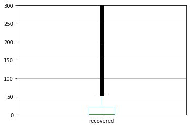

```python
plt.ylim(0, 300)
df.boxplot('recovered')
```

Также множественные выбросы

⚡ **Вывод:**

1. В датасете есть выбросы - ряд стран лидируют по числу зараженных, смертей и выздоровевших.
2. Поскольку наблюдения прямо связаны между собой в странах с большим числом зараженных должно быть большее число умерших и выздоровевших.

# 5 Подсчитаем летальность от COVID-19 на 07.04.2020 года

#### - определение летальности

- **[Летальность](https://ru.wikipedia.org/wiki/%D0%9B%D0%B5%D1%82%D0%B0%D0%BB%D1%8C%D0%BD%D0%BE%D1%81%D1%82%D1%8C)** — показатель медицинской статистики, равный отношению числа умерших от определённого заболевания или иного нарушения здоровья за определённый период времени к общему числу людей, имевших тот же диагноз в рамках того же периода времени. Обычно выражается в процентах. Показатель летальности не постоянен, он может изменяться между популяциями, а также с течением времени. Летальность зависит от разных факторов, которые могут включать особенности патогена в случае заболевания, состояние организма, внешние обстоятельства, способы лечения и качество ухода за больными. Расчётным периодом часто является год.

#### - формула для расчета

$$ \displaystyle {{умерло}\over{(умерло + вылечилось)}} \times 100 % $$

#### - подготовим данные для расчета

- Сгруппируем по странам и датам, отсортируем по дате и избавимся от дубликатов, чтобы оставить только последние заиксированные наблюдения, отберем только наблюдения с потвержденными случаями

```python
df_total = df.groupby(['country', 'date']).sum().reset_index().sort_values('date', ascending=False).drop_duplicates(subset = ['country'])
df_total = df_total[df_total['confirmed'] > 0]
```

#### - выведем общее число заболевших

```python
confirmed = df_total.confirmed.sum()
confirmed
```

```
1427031
```

#### - выведем общее число умерших

```python
deaths = df_total.deaths.sum()
deaths
```

```
81874
```

#### - выведем общее число выздоровевших

```python
recovered = df_total.recovered.sum()
recovered
```

```
300628
```

#### - расчитаем летальность по формуле и выведем итоговый отчет

```python
cfr = (df_total.deaths.sum() / (df_total.deaths.sum() + df_total.recovered.sum())) * 100
cfr
```

```
21.40485539944889
```

⚡ **Вывод:**

```python
explorer.reporter(confirmed, deaths, recovered)
```

```
1. По состоянию на 07.04.2020 года:
 - заболело 1427031 человек
 - умерло 81874 человек
 - выздоровело 300628 человек
2. На сегодняшний день, исходя из представленных данных ,принимая во внимание короткий период наблюдений летальность COVID-19 составляет 21.40 %
```

# 6 Визуализируем данные о числе зараженных на 07.04.2020 года

#### - визуализируем общую карту с числом подтвержденных случаев

```python
explorer.plotly_choropleth(df_total, z='confirmed', title='Подтвержденные случаи на 07.04.2020 года')
```

[interactive chart not shown]

#### - нарисуем столбчатый график с первыми десятью странами по числу выявленных зараженных

```python
top_ten = df_total.sort_values(by='confirmed', ascending=False).head(10)
```

```python
explorer.plotly_bar(top_ten, 'country', 'confirmed', 'confirmed', '', 'Число заболевших', 'Подтвержденные случаи на 07.04.2020 года')
```

[interactive chart not shown]

#### - визуализируем соотношение заболевших, умерших и выздоровевших для первых десяти странами по числу выявленных зараженных

```python
explorer.plotly_sided_bar(top_ten)
```

[interactive chart not shown]

#### - выведем три страны с самым большим числом заболевших на сегодняшний день

```python
top_ten.head(3)
```

|  | country | date | confirmed | deaths | recovered |
| --- | --- | --- | --- | --- | --- |
| 6460 | US | 04/07/2020 | 396223 | 12722 | 21763 |
| 5737 | Spain | 04/07/2020 | 141942 | 14045 | 43208 |
| 3012 | Italy | 04/07/2020 | 135586 | 17127 | 24392 |

#### - выведем статистику для России на сегодняшний день

```python
df_total[df_total['country'] == 'Russia']
```

|  | country | date | confirmed | deaths | recovered |
| --- | --- | --- | --- | --- | --- |
| 5111 | Russia | 04/07/2020 | 7497 | 58 | 494 |

# 7 Визуализируем динамику распространения COVID-19

#### - подготовим сводные данные по дате

```python
df_date = df[df['confirmed'] > 0]
df_date = df_date.groupby(['date','country']).sum().reset_index()
```

#### - визуализируем динамику распространения COVID-19

```python
explorer.plotly_animated_choropleth(df_date, color='confirmed', title='Распространие COVID-19 во времени')
```

[interactive chart not shown]